# Sentiment Analysis Pride and Prejudice

by Misja Bjørk Lauridsen

created on 22 November 2020 and updated 25-05-2026

#quick thoughts I am working to do a sentiment analysis on Pride and Prejudice by Jane Austen. A well known critic of gentry and society during the regency era of Great Britain. She often places her works within romance settings, as that is the expectation of women in that era. I expect the sentiment to be evenly split. Positive in its romance aspects and negative when describing society.

### Pride and Prejudice book:

```r
paj_path <- here::here("data", "prideandprejudice.pdf")
paj_text <- pdf_text(paj_path)
```

Some things to notice:

#Do you think it will work with any PDF? #No. Low quality scans of physical books, or pdfs with corruption present in the file will make it difficult or impossible to read the data within the file

```r
paj_p9 <- paj_text[9]
paj_p9
```

```
## [1] "\"Is that his design in settling here?\"\n\"Design! nonsense, how can you talk so! But it is very likely that he may fall in love\nwith one of them, and therefore you must visit him as soon as he comes.\"\n\"I see no occasion for that. You and the girls may go, or you may send them by\nthems…
```

### Some wrangling:

- Split up pages into separate lines (separated by `\n`) using `stringr::str_split()`
- Unnest into regular columns using `tidyr::unnest()`
- Remove leading/trailing white space with `stringr::str_trim()`

```r
paj_df <- data.frame(paj_text)%>%
 mutate(text_full=str_split(paj_text,pattern='\n'))%>%
 unnest(text_full)%>%
 mutate(text_full=str_trim(text_full))
```

Now each line, on each page, is its own row, with extra starting & trailing spaces removed.

### Get the tokens (individual words) in tidy format

Use `tidytext::unnest_tokens()` (which pulls from the `tokenizer`) package, to split columns into tokens. We are interested in *words*, so that’s the token we’ll use:

```r
paj_tokens <- paj_df %>%
     unnest_tokens(word, text_full)
# Each word has its own row!
```

Let’s count the words!

```r
paj_wc <- paj_tokens %>%
     count(word) %>%
     arrange(-n)
paj_wc
```

```
## # A tibble: 6,684 × 2
##    word      n
##    <chr> <int>
##  1 the    4529
##  2 to     4244
##  3 of     3754
##  4 and    3661
##  5 her    2224
##  6 i      2075
##  7 a      2002
##  8 in     1943
##  9 was    1849
## 10 she    1709
## # ℹ 6,674 more rows
```

OK…so we notice that a whole bunch of things show up frequently that we might not be interested in (“a”, “the”, “and”, etc.). These are called *stop words*. Let’s remove them.

### Remove stop words:

See `?stop_words` and `View(stop_words)`to look at documentation for stop words lexicons.

We will *remove* stop words using `tidyr::anti_join()`:

```r
paj_stop <- paj_tokens %>%
  anti_join(stop_words) %>%
  select(-paj_text)
```

Now check the counts again:

```r
paj_swc <- paj_stop %>%
     count(word) %>%
     arrange(-n)
```

If i wanted to get rid of the numbers in my text, I could do this:

```r
# This code will filter out numbers by asking:
# If you convert to as.numeric, is it NA (meaning those words)?
# If it IS NA (is.na), then keep it (so all words are kept)
# Anything that is converted to a number is removed

paj_no_numeric <- paj_stop %>%
  filter(is.na(as.numeric(word)))
```

### A word cloud of Pride and Prejudice words (non-numeric)

```r
length(unique(paj_no_numeric$word))
```

```
## [1] 6114
```

```r
#This tells us that pride and prejudice has 6114 unique words i.e. words no on the stopwords list and not numerical in category
# We probably don't want to include them all in a word cloud. Let's filter to only include the top 100 most frequent?
paj_top100 <- paj_no_numeric %>%
  count(word) %>%
  arrange(-n) %>%
  head(100)
paj_top100
```

```
## # A tibble: 100 × 2
##    word          n
##    <chr>     <int>
##  1 elizabeth   596
##  2 darcy       373
##  3 bennet      294
##  4 miss        283
##  5 jane        265
##  6 bingley     257
##  7 time        204
##  8 lady        182
##  9 sister      180
## 10 wickham     162
## # ℹ 90 more rows
```

Now I am making the word cloud

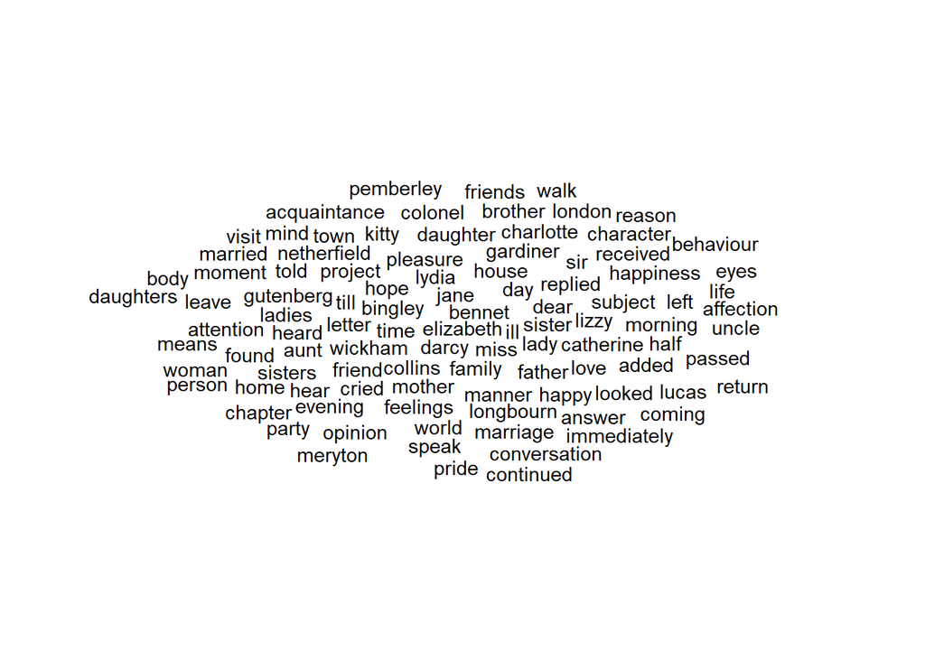

```r
paj_cloud <- ggplot(data = paj_top100, aes(label = word)) +
  geom_text_wordcloud() +
  theme_minimal()

paj_cloud
```

That’s underwhelming. Let’s customize it a bit: I am choosing the colours be the popular colours of fabrics during the regency for the gentry and nobility

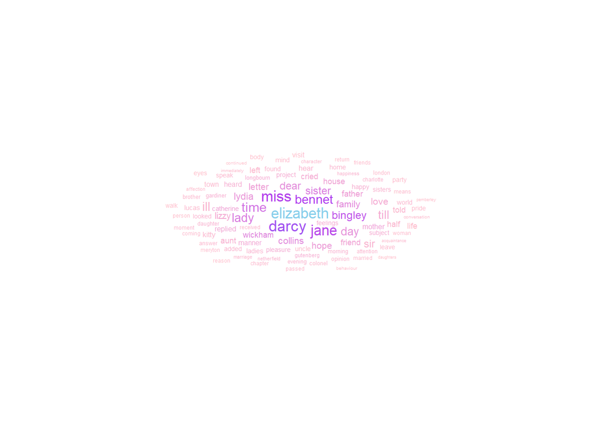

```r
ggplot(data = paj_top100, aes(label = word, size = n)) +
  geom_text_wordcloud_area(
    aes(color = n),
    mask = png::readPNG(
      system.file("extdata/hearth.png",
                  package = "ggwordcloud",
                  mustWork = TRUE)
    ),
    rm_outside = TRUE
  ) +
  scale_size_area(max_size = 12) +
  scale_color_gradientn(colors = c("pink", "purple", "skyblue")) +
  theme_minimal()
```

Cute! However the heartshape is lost upon being exported ‘:(’

### Sentiment analysis

The three general-purpose lexicons are

- AFINN from Finn Årup Nielsen,
- bing from Bing Liu and collaborators, and
- nrc from Saif Mohammad and Peter Turney

Let’s explore the sentiment lexicons.

“afinn”: Words ranked from -5 (very negative) to +5 (very positive)

```r
get_sentiments(lexicon = "afinn")
```

```
## # A tibble: 2,477 × 2
##    word       value
##    <chr>      <dbl>
##  1 abandon       -2
##  2 abandoned     -2
##  3 abandons      -2
##  4 abducted      -2
##  5 abduction     -2
##  6 abductions    -2
##  7 abhor         -3
##  8 abhorred      -3
##  9 abhorrent     -3
## 10 abhors        -3
## # ℹ 2,467 more rows
```

```r
# Let's look at the pretty positive words:
afinn_pos <- get_sentiments("afinn") %>%
  filter(value %in% c(3,4,5))

afinn_pos
```

```
## # A tibble: 222 × 2
##    word         value
##    <chr>        <dbl>
##  1 admire           3
##  2 admired          3
##  3 admires          3
##  4 admiring         3
##  5 adorable         3
##  6 adore            3
##  7 adored           3
##  8 adores           3
##  9 affection        3
## 10 affectionate     3
## # ℹ 212 more rows
```

bing: binary, “positive” or “negative”

```r
get_sentiments(lexicon = "bing")
```

```
## # A tibble: 6,786 × 2
##    word        sentiment
##    <chr>       <chr>
##  1 2-faces     negative
##  2 abnormal    negative
##  3 abolish     negative
##  4 abominable  negative
##  5 abominably  negative
##  6 abominate   negative
##  7 abomination negative
##  8 abort       negative
##  9 aborted     negative
## 10 aborts      negative
## # ℹ 6,776 more rows
```

nrc:https://saifmohammad.com/WebPages/NRC-Emotion-Lexicon.htm Includes bins for 8 emotions (anger, anticipation, disgust, fear, joy, sadness, surprise, trust) and positive / negative.

**Citation for NRC lexicon**: Crowdsourcing a Word-Emotion Association Lexicon, Saif Mohammad and Peter Turney, Computational Intelligence, 29 (3), 436-465, 2013.

Now nrc:

```r
get_sentiments(lexicon = "nrc")
```

```
## # A tibble: 13,872 × 2
##    word        sentiment
##    <chr>       <chr>
##  1 abacus      trust
##  2 abandon     fear
##  3 abandon     negative
##  4 abandon     sadness
##  5 abandoned   anger
##  6 abandoned   fear
##  7 abandoned   negative
##  8 abandoned   sadness
##  9 abandonment anger
## 10 abandonment fear
## # ℹ 13,862 more rows
```

Let’s do sentiment analysis on the Pride and Prejudice text data using afinn, and nrc.